# Métodos no paramétricos para enfrentar datos numéricos problemáticos

2025-11-28

#### **Contexto**

*En el trabajo de título de una estudiante del DIINF se reportan tiempos de ejecución (en milisegundos) y la cercanía con la solución óptima (en por ciento) de la mejor solución encontrada con tres versiones de un algoritmo genético para resolver instancias del problema del vendedor viajero disponibles en repositorios públicos. Ahora debe enfrentar el análisis de estos datos, por que está solicitando ayuda de las y los estudiantes de Estadística Inferencial.*

#### **Pregunta 1.**

**Observando los datos, la memorista sospecha que hay diferencias significativas en el tiempo de ejecución entre las versiones A y C del algoritmo cuando las instancias tienen 60 o más nodos. ¿Los datos respaldan la intuición de la memorista?** **Para responder, filtren los datos para tener las instancias con 60 o más nodos y seleccionen las columnas de los tiempos de ejecución de las versiones A y C en formato ancho. Usando como semilla el valor 73, obtenga muestras aleatorias independientes de 24 tiempos registrados por la versión A y 20 tiempos registrados por la versión C del algoritmo. Realicen un análisis estadístico pertinente (enunciar hipótesis, revisar condiciones, seleccionar pruebas ómnibus y post-hoc según corresponda) para responder la pregunta planteada, utilizando pruebas no paramétricas de ser necesario.**

Para la responder la pregunta enunciada, en un contexto de 2 muestras independientes (considerando que los tiempos de las instancias son muestras aleatorias, por lo que no debiesen estar correlacionadas) con variable cuantitativa continua (más que intervalos iguales), se propone las siguientes hipotesis; como hipotesis nula se tiene que el tiempo promedio de ejecución del algoritmo A, es el mismo que del algoritmo C; como hipotesis alternativa se tiene que el tiempo promedio de ejecución del algoritmo A, es diferente del algoritmo C. Sea $t_a$ el tiempo del algoritmo A y $t_c$ el tiempo del algoritmo C.

$$H_0: \mu_{t_a} = \mu_{t_c} \\ H_a:
\mu_{t_a} \neq \mu_{t_c}$$

Dada las hipótesis, un test de t-student para 2 muestras es adecuada, siempre que se tengan las condiciones necesarias para realizarla, se realizara con un grado de significancia del 0.05 por el momento. La primera condición se cumple al tener como variable dependiente el tiempo, cumple con escala de intervalos iguales y más;la segunda condición de observaciones independientes se cumple al ser tiempos de ejecuciones de diferentes instancias de solución de algoritmos ;la tercera condición de muestras independientes, se cumple al seleccionar de forma aleatoria muestras del algoritmo A y algoritmo C, por lo que los tiempos son independientes Y por ultimo la cuarta condición es que las observaciones provienen de una distribucion cercana a la normal, con ello procedemos a una prueba normalidad Shapiro-Wilk de las 2 muestras.

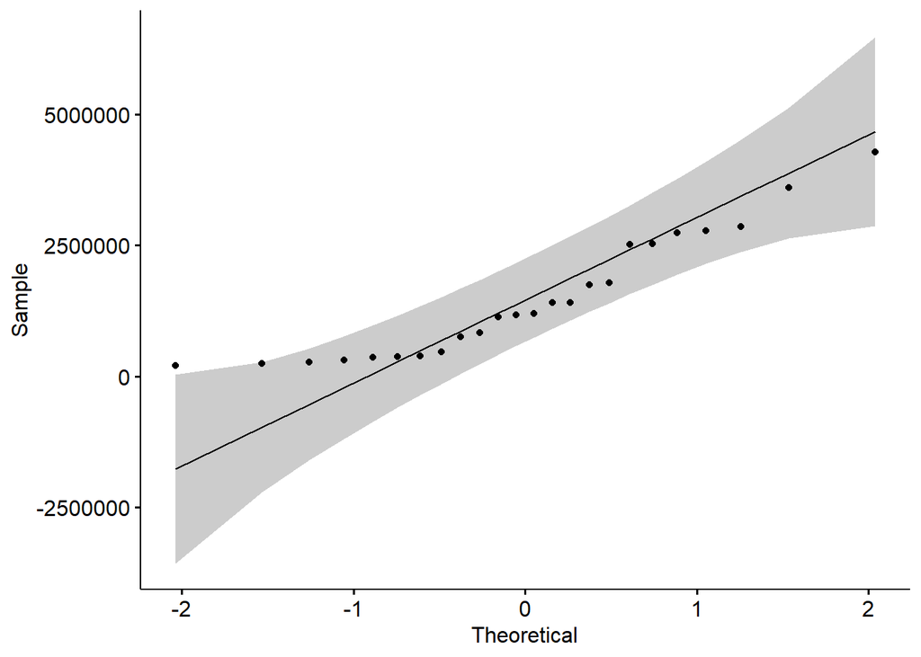

```r
AGrapNorm = ggqqplot(muestraA)
AGrapNorm
```

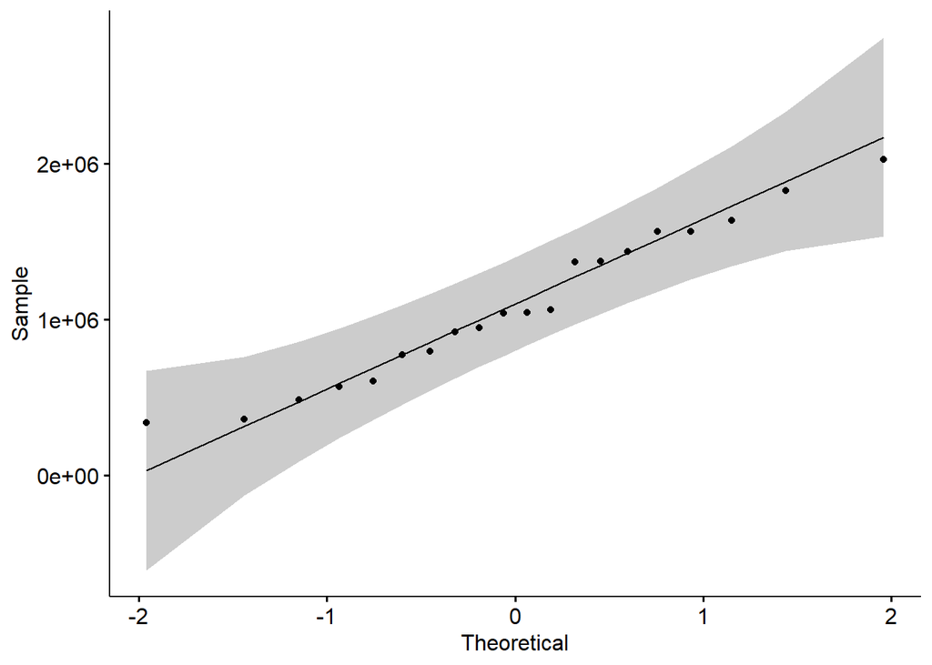

```r
CGrapNorm = ggqqplot(muestraC)
CGrapNorm
```

```r
shapiro.test(muestraA)
```

```
##
##  Shapiro-Wilk normality test
##
## data:  muestraA
## W = 0.89435, p-value = 0.01636
```

```r
shapiro.test(muestraC)
```

```
##
##  Shapiro-Wilk normality test
##
## data:  muestraC
## W = 0.96348, p-value = 0.6155
```

Los resultados de normalidad Shapiro-Wilk y los graficos Q-Q plot, demuestran que falta evidencia estadistica sobre la normalidad de la poblacion de la procedencia de los datos de la muestraA, dado que el p-value de la muestra A es de 0.01, no se puede afirmar normalidad. Por lo que se optara por tests no parametricos para no depender de la distribucion subyacente. Adicionalmente, el tamaño de las muestras, sea A y C respectivamente, es de 24 y 20, siendo menor a lo aceptable por la prueba t-student que es 30. La prueba de homocedasticidad se puede omitir debido a las evidencias anteriores.

Dado que las variables de las muestras son continuas, independientes y ordinales (considerando que un valor mayor corresponde a una ejecución más lenta y un valor más bajo, una ejecución más rápida), es adecuado el uso del test de suma de rangos de Wilcoxon para muestras grandes (considerando que son mayores a 5)

Con ello podemos formular las siguientes hipotesis:
$$H_0: \ \text{Las distribuciones de los tiempos de ejecucion para las
versiones A y C son identicas} \\
H_a: \text{Las distribuciones de los tiempos de ejecución para las
versiones A y C son diferentes (osea que uno es más rapido que otro)}$$
Ya habiendo formulado las hipotesis y comprobado las condiciones de la prueba, se procedera con el test.

```r
wilcox.test(muestraA,muestraC,paired=FALSE,alternative="two.sided",mu=0,conf.level = 0.05)
```

```
##
##  Wilcoxon rank sum exact test
##
## data:  muestraA and muestraC
## W = 260, p-value = 0.649
## alternative hypothesis: true location shift is not equal to 0
```

Dado el tamaño de la muestra y los criterios de la funcion wilcox, se tomo la versión exacta del test. El p-value entregado por el test de Wilcoxon, es de 0.649, siendo bastante más grande a nuestro grado de significancia 0.05, por lo que fallamos en rechazar la hipotesis nula, no hay suficiente evidencia estadistica para poder respaldar la intuición del memorista.

#### **Pregunta 2.**

**La memorista también sospecha que, al comparar las mismas instancias de iguales características, las mejores soluciones encontradas por las versiones A y B tienen rendimientos distintos. ¿Estará en lo cierto?** **Para responder, filtren los datos para tener las instancias con 60 o más nodos y seleccionen las columnas con el mejor rendimiento de las versiones A y B en formato ancho. Usando como semilla el valor 13, obtengan una muestra aleatoria de 22 instancias. Realicen un análisis estadístico pertinente (enunciar hipótesis, revisar condiciones, seleccionar pruebas ómnibus y post-hoc según corresponda) para responder la pregunta planteada, utilizando pruebas no paramétricas de ser necesario.**

A continuacion se plantean las hipotisis:

$$H_0: \ \text{La mediana de las diferencias (B-A) es igual a 0} \\
H_a: \text{La mediana (B-A) es distinta de 0}$$

Para la resolucion, se utilizara la prueba de Wilcoxon de rangos con signo (pareada y bilateral). Notemos que, las observaciones no son independientes y que el rendimiento, al ser un porcentaje (escala de razon) si cumple con que la medicion debe ser a lo menos ordinal.

```r
wilcox.test(A2, B2, paired = TRUE, alternative = "two.sided")
```

```
##
##  Wilcoxon signed rank exact test
##
## data:  A2 and B2
## V = 219, p-value = 0.001673
## alternative hypothesis: true location shift is not equal to 0
```

Por utlimo, se puede ver que el test arrojo un p-value de $p = 0.0017$ aprox., lo que nos indica rechazar la hipotesis nula, es decir, la mediana de las diferencias (B-A) difiere de ser igual a 0.

#### **Pregunta 3.**

**La memorista sospecha que hay diferencias significativas en el tiempo de ejecución entre las versiones del algoritmo cuando las instancias de prueba tienen 50 o más nodos. ¿Los datos respaldan la intuición de la memorista?** **Para responder, filtren los datos para tener las instancias con 50 o más nodos y seleccionen las columnas con los tiempos de ejecución registrados (en formato ancho). Usando como semilla el valor 43, obtengan muestras aleatorias independientes de 15, 15 y 13 tiempos registrados por las versiones A, B y C, respectivamente. Realicen un análisis estadístico pertinente (enunciar hipótesis, revisar condiciones, seleccionar pruebas ómnibus y post-hoc según corresponda) para responder la pregunta planteada, utilizando pruebas no paramétricas de ser necesario.**

Las hipotesis a contrastar (Hipotesis omnibus: Kruskal-Wallis) son:
$$H_0: \ \text{Las dsitribuciones de tiempos de A, B y C son iguales (si
las formas son comparables, las medianas tambien lo son)} \\
H_a: \text{Al menos una de las distribuciones (medianas) difiere}$$
En este caso las condiciones se cumplen dado que, primero, es tiempo en milisegundos (escala de razon), por lo que es al menos ordinal, tambien se asume independencia dentro de cada grupo y entre los grupos, dado que se toman muestras independientes tanto para A, B y C (con semilla 43) y por utlimo vemos que se tienen 3 niveles (A, B y C) por lo que la ultima condicion tambien se cumple.

```r
kruskal.test(list(A3, B3, C3))  # omnibus
```

```
##
##  Kruskal-Wallis rank sum test
##
## data:  list(A3, B3, C3)
## Kruskal-Wallis chi-squared = 8.4678, df = 2, p-value = 0.0145
```

```r
# post-hoc: pares con Holm
pAB <- wilcox.test(A3, B3, paired = FALSE)$p.value
pAC <- wilcox.test(A3, C3, paired = FALSE)$p.value
pBC <- wilcox.test(B3, C3, paired = FALSE)$p.value
p.adjust(c(pAB, pAC, pBC), method = "holm")  # orden: AB, AC, BC
```

```
## [1] 0.02962447 0.12950279 0.12950279
```

#### **Pregunta 4.**

**La memorista también sospecha que, al comparar las mismas instancias con iguales características, las mejores soluciones encontradas por las diferentes versiones del algoritmo tienen rendimientos distintos. ¿Estará en lo cierto?** **Para responder, filtren los datos para tener las instancias con 50 o más nodos y seleccionen las columnas con los mejores rendimientos registrados. Usando como semilla el valor 71, obtengan una muestra aleatoria de 22 instancias. Lleven los datos a formato largo y utilicen una prueba no paramétrica apropiada para analizar los datos obtenidos. Realicen un análisis estadístico pertinente (enunciar hipótesis, revisar condiciones, seleccionar pruebas ómnibus y post-hoc según corresponda) para responder la pregunta planteada, utilizando pruebas no paramétricas de ser necesario.** Las Hipotesis (omnibus: Friedman, datos pareados) propuestas son:
$$H_0: \ \text{Las posiciones/rangos medianos de rendimiento son iguales
entre A, B y C (no hay efecto de version)} \\
H_a: \text{Al menos una version de ella difiere}$$

Para revisar las condiciones requeridas para la prueba de Friedman se tiene que, el rendimiento es un porcentaje por lo que la primera condicion de ordinalidad se cumple, luego, como se mencino anteriormente, las muestras dentro de cada bloque de las tres mediciones (A, B, C) no son independientes (por eso es un diseño pareado) y por ultimo se siguen manteniendo 3 niveles al igual que la pregunta anterior (A, B, C).

```r
# Friedman
friedman.test(as.matrix(sub[, c("mejor.A","mejor.B","mejor.C")]))
```

```
##
##  Friedman rank sum test
##
## data:  as.matrix(sub[, c("mejor.A", "mejor.B", "mejor.C")])
## Friedman chi-squared = 13.364, df = 2, p-value = 0.001253
```

La prueba de Friedman nos entrego $\chi^2_F$$= 13.364$, $gl = 2$ y un p-value $p = 0.001253$ por lo que se rechaza la Hipotesis Nula, es decir, hay diferencias globales de rendimiento entre versiones.

```r
# post-hoc pareado con Holm
pAB <- wilcox.test(sub$mejor.A, sub$mejor.B, paired = TRUE)$p.value
pAC <- wilcox.test(sub$mejor.A, sub$mejor.C, paired = TRUE)$p.value
pBC <- wilcox.test(sub$mejor.B, sub$mejor.C, paired = TRUE)$p.value
p.adjust(c(pAB, pAC, pBC), method = "holm")
```

```
## [1] 0.0004363159 0.0502777100 0.1206774712
```

Por ultimo, las pruebas post-hoc nos dice que *AvsB* tendria un efecto grande (0.00044 -> significativo), *AvsC* y *BvsC* (0.05 y 0.12 respectivamente) no es significativo, por lo que solo se puede decir que A supera a B en rendimiento y que en (A y C) y (B y C) no se detecta diferencia.